# HW5-1

Renjie Liu

3/2/2021

#### 1.Load in Anil’s clustreg and clustreg.predict functions; Dataset is: GermanCreditData.

#### 2. Amount will be the dependent variable. 3.Use the other 6 numeric variables as independent variables. If you use caret package data, this will be columns 1 and 3 through 7 (typo is assignment). Align your data frame for training and test so that amount in the first column and the following 6 are the other 6 numeric variables.

```r
data <- read.csv('GermanCredit.csv')
set.seed(123)
data <- data[,-1]
data1 <- data[,c(2,1,3:7)]
train_index<- sample(nrow(data1), size = 0.7*nrow(data1))
train <- data1[train_index,]
test <- data1[-train_index,]

test <- as.data.frame(test)
```

```r
clustreg=function(dat,k,tries,sed,niter)
{

set.seed(sed)
dat=as.data.frame(dat)
rsq=rep(NA,niter)
res=list()
rsq.best=0
    for(l in 1:tries)
    {

    c = sample(1:k,nrow(dat),replace=TRUE)
    yhat=rep(NA,nrow(dat))
    for(i in 1:niter)
    {
        resid=pred=matrix(0,nrow(dat),k)
        for(j in 1:k)
        {
            pred[,j]=predict(glm(dat[c==j,],family="gaussian"),newdata=dat)
            resid[,j] = (pred[,j]-dat[,1])^2
        }

    c = apply(resid,1,which.min)
    for(m in 1:nrow(dat)) {yhat[m]=pred[m,c[m]]}
    rsq[i] = cor(dat[,1],yhat)^2
    }

    if(rsq[niter] > rsq.best)
        {
        rsq.best=rsq[niter]
        l.best=l
                c.best=c
        yhat.best=yhat
        }
    }

    res=list("Complete")
    for(i in k:1) {res=list(summary(lm(dat[c.best==i,])),res)}

    return(list(data=dat,nclust=k,tries=tries,seed=sed,rsq.best=rsq.best,number.loops=niter, Best.try=l.best,cluster=c.best,results=res))
}
```

#### 4. Perform clusters wise regression for 1, 2, and 3 clusters. Arguments for clustreg formula are: dat, k, tries, seed, niter

```r
model1 <- clustreg(train,1,sed = 1234, tries = 1, niter = 1)


model2 <- clustreg(train,2,sed = 1234, tries = 2, niter = 10)


model3 <- clustreg(train,3,sed = 1234, tries = 2, niter = 10)
```

#### Explore the attributes and find the best R squared for each cluster solution. Plot this r squared as a function of number of clusters

```r
model1$results
```

```
## [[1]]
##
## Call:
## lm(formula = dat[c.best == i, ])
##
## Residuals:
##     Min      1Q  Median      3Q     Max
## -5993.8 -1199.5  -297.7   554.3 12214.7
##
## Coefficients:
##                           Estimate Std. Error t value Pr(>|t|)
## (Intercept)               1781.971    464.183   3.839 0.000135 ***
## Duration                   151.944      6.476  23.464  < 2e-16 ***
## InstallmentRatePercentage -800.104     71.084 -11.256  < 2e-16 ***
## ResidenceDuration           41.270     75.854   0.544 0.586563
## Age                         20.318      7.346   2.766 0.005831 **
## NumberExistingCredits       73.086    144.858   0.505 0.614048
## NumberPeopleMaintenance   -176.190    224.764  -0.784 0.433373
## ---
## Signif. codes:  0 '***' 0.001 '**' 0.01 '*' 0.05 '.' 0.1 ' ' 1
##
## Residual standard error: 2115 on 693 degrees of freedom
## Multiple R-squared:  0.483,  Adjusted R-squared:  0.4785
## F-statistic: 107.9 on 6 and 693 DF,  p-value: < 2.2e-16
##
##
## [[2]]
## [[2]][[1]]
## [1] "Complete"
```

```r
model2$results
```

```
## [[1]]
##
## Call:
## lm(formula = dat[c.best == i, ])
##
## Residuals:
##     Min      1Q  Median      3Q     Max
## -3422.9 -1118.8  -422.0   502.2  9191.7
##
## Coefficients:
##                            Estimate Std. Error t value Pr(>|t|)
## (Intercept)                7315.688    724.560  10.097  < 2e-16 ***
## Duration                    136.198      9.458  14.400  < 2e-16 ***
## InstallmentRatePercentage  -895.742    102.564  -8.733  < 2e-16 ***
## ResidenceDuration           101.738    110.276   0.923  0.35701
## Age                          30.864     10.000   3.086  0.00222 **
## NumberExistingCredits     -2750.049    218.467 -12.588  < 2e-16 ***
## NumberPeopleMaintenance     -37.127    307.979  -0.121  0.90413
## ---
## Signif. codes:  0 '***' 0.001 '**' 0.01 '*' 0.05 '.' 0.1 ' ' 1
##
## Residual standard error: 1956 on 287 degrees of freedom
## Multiple R-squared:  0.6916, Adjusted R-squared:  0.6852
## F-statistic: 107.3 on 6 and 287 DF,  p-value: < 2.2e-16
##
##
## [[2]]
## [[2]][[1]]
##
## Call:
## lm(formula = dat[c.best == i, ])
##
## Residuals:
##     Min      1Q  Median      3Q     Max
## -3685.4  -621.0   -20.5   654.9  5636.2
##
## Coefficients:
##                            Estimate Std. Error t value Pr(>|t|)
## (Intercept)               -2927.929    314.489  -9.310   <2e-16 ***
## Duration                    100.793      4.208  23.954   <2e-16 ***
## InstallmentRatePercentage  -456.515     43.896 -10.400   <2e-16 ***
## ResidenceDuration             7.511     46.415   0.162    0.872
## Age                           4.739      4.774   0.993    0.321
## NumberExistingCredits      4703.867    171.680  27.399   <2e-16 ***
## NumberPeopleMaintenance    -214.061    143.163  -1.495    0.136
## ---
## Signif. codes:  0 '***' 0.001 '**' 0.01 '*' 0.05 '.' 0.1 ' ' 1
##
## Residual standard error: 988.6 on 399 degrees of freedom
## Multiple R-squared:  0.821,  Adjusted R-squared:  0.8183
## F-statistic: 304.9 on 6 and 399 DF,  p-value: < 2.2e-16
##
##
## [[2]][[2]]
## [[2]][[2]][[1]]
## [1] "Complete"
```

```r
model3$results
```

```
## [[1]]
##
## Call:
## lm(formula = dat[c.best == i, ])
##
## Residuals:
##     Min      1Q  Median      3Q     Max
## -2729.6  -333.1   -65.3   298.6  5794.1
##
## Coefficients:
##                             Estimate Std. Error t value Pr(>|t|)
## (Intercept)               10919.2314   383.2787  28.489   <2e-16 ***
## Duration                     51.8312     4.8573  10.671   <2e-16 ***
## InstallmentRatePercentage -2751.9134    64.9627 -42.361   <2e-16 ***
## ResidenceDuration            -0.8953    54.6112  -0.016   0.9869
## Age                          11.2394     4.9280   2.281   0.0235 *
## NumberExistingCredits       -93.4095   100.4562  -0.930   0.3534
## NumberPeopleMaintenance     119.2850   157.2139   0.759   0.4488
## ---
## Signif. codes:  0 '***' 0.001 '**' 0.01 '*' 0.05 '.' 0.1 ' ' 1
##
## Residual standard error: 830.2 on 225 degrees of freedom
## Multiple R-squared:  0.9169, Adjusted R-squared:  0.9147
## F-statistic:   414 on 6 and 225 DF,  p-value: < 2.2e-16
##
##
## [[2]]
## [[2]][[1]]
##
## Call:
## lm(formula = dat[c.best == i, ])
##
## Residuals:
##     Min      1Q  Median      3Q     Max
## -4062.5  -934.9  -354.9   627.5  5487.4
##
## Coefficients:
##                           Estimate Std. Error t value Pr(>|t|)
## (Intercept)                1191.71    1185.26   1.005   0.3176
## Duration                    230.37      15.16  15.198  < 2e-16 ***
```

[output cut: 28 more lines]

```
## ResidenceDuration           17.949     37.638   0.477   0.6337
## Age                          4.273      3.987   1.072   0.2845
## NumberExistingCredits      -28.390     78.809  -0.360   0.7189
## NumberPeopleMaintenance    -46.574    113.526  -0.410   0.6819
## ---
## Signif. codes:  0 '***' 0.001 '**' 0.01 '*' 0.05 '.' 0.1 ' ' 1
##
## Residual standard error: 787.4 on 372 degrees of freedom
## Multiple R-squared:  0.7486, Adjusted R-squared:  0.7445
## F-statistic: 184.6 on 6 and 372 DF,  p-value: < 2.2e-16
##
##
## [[2]][[2]][[2]]
## [[2]][[2]][[2]][[1]]
## [1] "Complete"
```

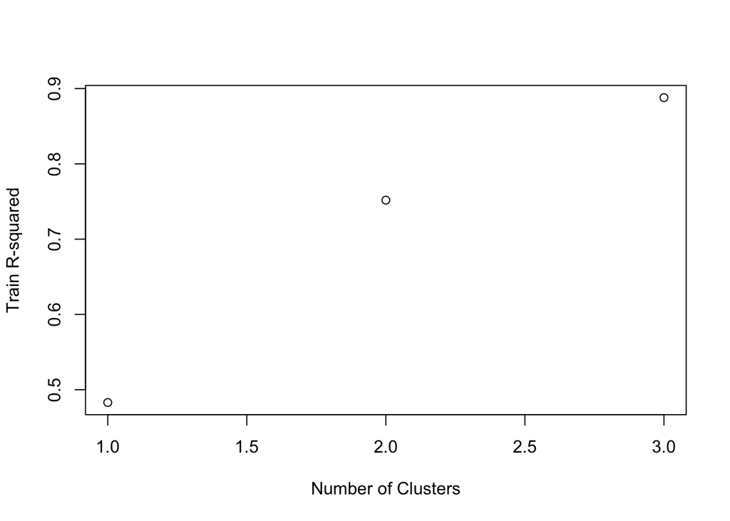

```r
r2 <- c(model1$rsq.best,model2$rsq.best,model3$rsq.best)
x1 <- c(1,2,3)
plot(x = x1, y = r2, xlab = 'Number of Clusters',ylab = 'Train R-squared')
```

#### 6. Perform holdout on each of the 3 cluster models using the clustreg.predict function. Arguments are the appropriate train model and holdout data

```r
clustreg.predict=function(results,newdat){

    yhat=rep(NA,nrow(newdat))
    resid=pred=matrix(0,nrow(newdat),length(table(results$cluster)))

        for(j in 1:length(table(results$cluster))){
            pred[,j]=predict(glm(results$data[results$cluster==j,],family="gaussian"),newdata=newdat)
            resid[,j] = (pred[,j]-newdat[,1])^2
        }

    c = apply(resid,1,which.min)
    for(m in 1:nrow(newdat)) {yhat[m]=pred[m,c[m]]}
    rsq = cor(newdat[,1],yhat)^2

return(list(results=results,newdata=newdat,cluster=c,yhat=yhat,rsq=rsq))

}
```

```r
pred1 <- clustreg.predict(model1,test)


pred2 <- clustreg.predict(model2,test)


pred3 <- clustreg.predict(model3,test)
```

#### 7. Find the best r squared from each of the holdout models. Show a table of R squared from train, r squared from holdout, and percentage decrease from train to holdout R squared: (Train R square – Holdout R square)/ Train R square.

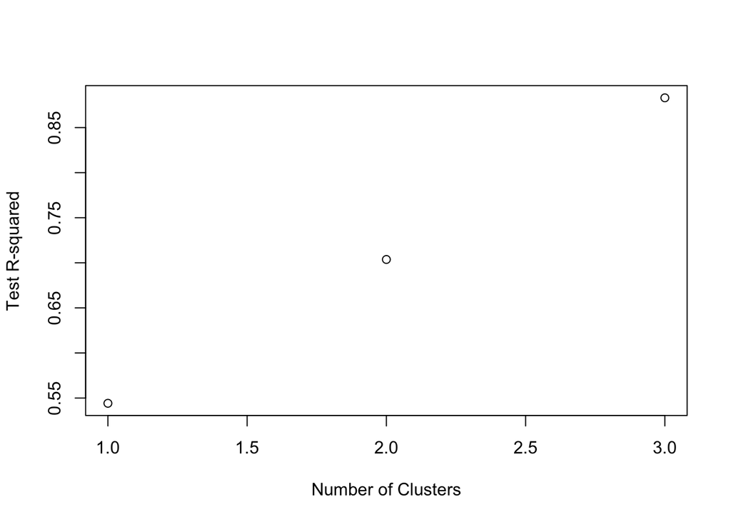

```r
r2 <- c(pred1$rsq,pred2$rsq,pred3$rsq)
x1 <- c(1,2,3)
plot(x = x1, y = r2, xlab = 'Number of Clusters',ylab = 'Test R-squared')
```

```r
testrsq <- c(pred1$rsq,pred2$rsq,pred3$rsq)
trainrsq <- c(model1$rsq.best,model2$rsq.best,model3$rsq.best)
table <- data.frame(trainrsq,testrsq)
table$rsq_decrease_percentage <- (table$trainrsq-table$testrsq)/table$trainrsq*100
table
```

```
##    trainrsq   testrsq rsq_decrease_percentage
## 1 0.4829876 0.5441932             -12.6722976
## 2 0.7518189 0.7037048               6.3996907
## 3 0.8879761 0.8829854               0.5620346
```